# Session 3: Inference and Matrix Foundations in SLR

# 1. Hypothesis Testing and Model Diagnostics

> **1.1 Data Generation:** Construct a dataset ($n = 20$) where $X \sim U(0,10)$ and $Y$ is generated with $\beta_{0} = 2$, $\beta_{1} = 3$, and $\epsilon \sim N(0, 10^{2})$.

> **1.2 Statistical Inference:** Fit the model using `lm()` and analyze the output via `summary()`.
- Identify the $t$-statistic and $p$-value for the two-sided test ($H_0: \beta_1 = 0$ vs $H_1: \beta_1 \ne 0$) and two one-sided tests ($H_0: \beta_1 \ge 0$ vs $H_1: \beta_1 < 0$ and $H_0: \beta_1 \le 0$ vs $H_1: \beta_1 > 0$).
- Manually determine the critical values for both one-sided ($\alpha = 0.05$) and two-sided ($\alpha = 0.05$) tests using the $t$-distribution.

> **1.3 Interpretation:** Formulate a conclusion regarding the null hypothesis $H_{0}: \beta_{1} = 0$ based on the calculated $p$-value and critical values.

```r
# Clear environment
rm(list = ls())
set.seed(101) # For reproducibility

# 1.1 Data Generation
ns  <- 20
xs  <- runif(ns, 0, 10)
bt0 <- 2
bt1 <- 3
ys  <- bt0 + bt1 * xs + rnorm(ns, sd = 10)
mod1   <- lm(ys ~ xs)
df.val <- ns - 2

# 1.2: Fit model, identify t-statistic and p-value for slope (beta.1)
# 1.3: Manually determine critical values and interpret H0: beta.1 = 0
summary(mod1)
sum.mod1 <- summary(mod1)
sum.mod1$coefficients["xs", ]
coef(sum.mod1)
obs.t <- sum.mod1$coefficients["xs", 3]

# two-sided test
obs.t
(1 - pt(obs.t, df = df.val)) * 2

# note that the last element shown above is the p-value for the two-sided test (H.1: beta.1 != 0).
# for a one-sided test for the alternative beta.1 >= 0, the test statistic and p-value are
obs.t
1 - pt(obs.t, df = df.val) # same as sum.mod1$coefficients["xs", 4]/2

# for a one-sided test for the alternative beta.1 <= 0, the test statistic and p-value are
obs.t
pt(obs.t, df = df.val) # same as 1 - sum.mod1$coefficients["xs", 4]/2

# Visualization
curve(dt(x, df = df.val), xlim = c(-5, 6), main = 't-distribution')

# Define the sequence of X points from the left limit to the observed t
x.left <- seq(-5, obs.t, length.out = 200)
y.left <- dt(x.left, df = df.val)
polygon(c(x.left, obs.t, -5), c(y.left, 0, 0), col = "green", border = NA)

# Define the sequence of X points from the observed t to the right limit
x.right <- seq(obs.t, 5, length.out = 200)
y.right <- dt(x.right, df = df.val)
polygon(c(x.right, 5, obs.t), c(y.right, 0, 0), col = "yellow", border = NA)

# Re-draw the curve and add the vertical line for a clean aesthetic finish
curve(dt(x, df = df.val), add = TRUE, lwd = 2)
abline(v = obs.t, lwd = 3, col = 'red')

# Add text to explain the regions
text(0,   0.08, expression(paste("p-value for ", H[1], ": ", beta[1] < 0)))
text(4.8, 0.08, expression(paste("p-value for ", H[1], ": ", beta[1] > 0)))

alpha           <- 0.05
cv.2sided       <- qt(1 - alpha/2, df = ns - 2)       # Two-tailed (Two-sided) Critical Value
cv.1sided.right <- qt(1 - alpha,   df = ns - 2)        # One-tailed (Right-tailed) Critical Value
cv.1sided.left  <- qt(alpha,       df = ns - 2)        # One-tailed (Left-tailed) Critical Value
cat("Two-tailed Critical Value (alpha=0.05):",           cv.2sided, "\n")
cat("Right-tailed (Upper) Critical Value (alpha=0.05):", cv.1sided.right, "\n")
cat("Left-tailed (Lower) Critical Value (alpha=0.05):",  cv.1sided.left, "\n")
```

**Results**

```
##
## Call:
## lm(formula = ys ~ xs)
##
## Residuals:
##      Min       1Q   Median       3Q      Max
## -17.8635  -6.1870   0.3746   6.7620  17.7112
##
## Coefficients:
##             Estimate Std. Error t value Pr(>|t|)
## (Intercept)    2.006      4.633   0.433  0.67020
## xs             2.515      0.813   3.094  0.00626 **
## ---
## Signif. codes:  0 '***' 0.001 '**' 0.01 '*' 0.05 '.' 0.1 ' ' 1
##
## Residual standard error: 9.206 on 18 degrees of freedom
## Multiple R-squared:  0.3472, Adjusted R-squared:  0.3109
## F-statistic: 9.572 on 1 and 18 DF,  p-value: 0.006262
```

```
## Coefficients for xs:
```

```
##    Estimate  Std. Error     t value    Pr(>|t|)
## 2.515357540 0.812996585 3.093933709 0.006261848
```

```
## obs.t: 3.093934
```

```
## p-value (two-sided): 0.006261848
```

```
## p-value (right-tailed): 0.003130924
```

```
## p-value (left-tailed): 0.9968691
```

```
## Two-tailed Critical Value (alpha=0.05): 2.100922
```

```
## Right-tailed (Upper) Critical Value (alpha=0.05): 1.734064
```

```
## Left-tailed (Lower) Critical Value (alpha=0.05): -1.734064
```

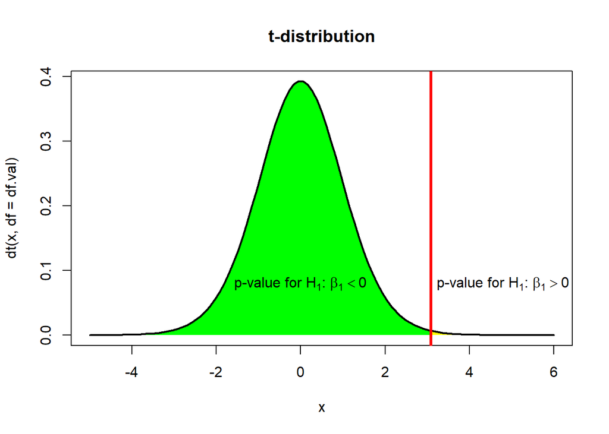

**Answer**

1.3 Interpretation

At the $\alpha = 0.05$ significance level, we evaluate the three hypothesis tests:

1) Two-sided Test ($H_0: \beta_1 = 0$ vs $H_1: \beta_1 \neq 0$)

- **Decision:** Since $|t| =$ 3.0939 $>$ 2.1009 (or $p =$ 0.0063 $< 0.05$), we **reject $H_0$**.
- **Conclusion:** There is a statistically significant linear relationship between $X$ and $Y$.

2) Right-tailed Test ($H_0: \beta_1 \le 0$ vs $H_1: \beta_1 > 0$)

- **$p$-value:** For a positive observed $t$, the one-sided $p$-value is half of the two-sided $p$-value (0.00626 $/2 =$ 0.00313).
- **Decision:** Since $p =$ 0.00313 $< 0.05$, we **reject $H_0$**.
- **Conclusion:** There is significant evidence that the slope $\beta_1$ is positive.

3) Left-tailed Test ($H_0: \beta_1 \ge 0$ vs $H_1: \beta_1 < 0$)

- **Decision:** Since $t =$ 3.0939 is in the opposite direction of $H_1$ ($t > 0$ while $H_1$ expects $t < 0$), we **fail to reject $H_0$**.
- **Conclusion:** There is no evidence to suggest that the slope $\beta_1$ is negative.

# 2. Matrix Algebra for OLS Estimators

> **2.1 Design Matrix:** Construct the design matrix $\mathbf{X}$ (including the intercept column) using base R functions.

> **2.2 Manual Estimation:** Calculate the estimated parameter vector
> $$\widehat{\boldsymbol{\beta}} =
> \left(\mathbf{X}^{T}\mathbf{X}\right)^{-1}\mathbf{X}^{T}\mathbf{y}$$
> using matrix multiplication operators.

> **2.3 Verification:** Compare your manually computed $\widehat{\boldsymbol{\beta}}$ values with the results from the `coef()` function to ensure mathematical consistency.

```r
# 2.1 Construct Design Matrix (X)
# Adding a column of 1s for the intercept
Xs <- cbind(1, xs)

# 2.2 Calculate Beta via OLS Matrix Formula: (X'X)^-1 X'y
# %*% is matrix multiplication; t() is transpose; solve() is inverse
beta.matrix <- solve(t(Xs) %*% Xs) %*% t(Xs) %*% ys

# 2.3 Comparison
cat("\n--- Comparison of Coefficients ---\n")
cat("Matrix Method:\n"); print(as.vector(beta.matrix))
cat("lm() Method:\n");   print(coef(mod1))
```

**Results**

```
## --- Comparison of Coefficients ---
```

```
## Matrix Method:
```

```
## [1] 2.005749 2.515358
```

```
## lm() Method:
```

```
## (Intercept)          xs
##    2.005749    2.515358
```

# 3. Pointwise Confidence Intervals (CI)

> **3.1 Built-in Prediction:** Use the `predict()` function to calculate the 95% confidence intervals (CIs) for the expected value of $Y$ at specific points $\mathbf{x} = \{2, 5, 10\}$.

> **3.2 Mathematical Formulation:** Manually calculate the 95% CI for the same points using the standard error formula:
> $$\text{SE}\left(\widehat{E}\left[Y \mid
> x_{h}\right]\right) = \hat{\sigma}\sqrt{\frac{1}{n} + \frac{(x_h -
> \bar{x})^2}{\sum_{i=1}^{n}(x_i - \bar{x})^2}}$$

> **3.3 Visual Comparison:** Create a scatter plot of the data and add the fitted regression line.
- Plot the pointwise confidence bands across the entire range of $x$ using dashed lines to visualize the uncertainty of the estimated mean. To construct these bands, first generate an equally-spaced sequence of points along the x-axis and calculate the confidence interval for the expected response at each point.

```r
# 3.1 Using predict() function
x.new   <- c(2, 5, 10)
new.dat <- data.frame(xs = x.new)
ci.predict <- predict(mod1, newdata = new.dat, interval = "confidence", level = 0.95)

# 3.2 Manual Calculation by Formula
# Extracting necessary components from summary
s.mod     <- summary(mod1)
sigma.hat <- s.mod$sigma
x.bar     <- mean(xs)
ssx       <- var(xs) * (ns - 1) # Sum of Squares for X

# estimated value at x.new
y.hat.manual <- cbind(1, x.new) %*% coef(mod1)

se.pointwise <- sigma.hat * sqrt(1/ns + (x.new - x.bar)^2 / ssx)
margin.error <- se.pointwise * qt(0.975, df = mod1$df.residual)

ci.manual <- cbind(y.hat.manual, y.hat.manual - margin.error, y.hat.manual + margin.error)
colnames(ci.manual) <- c("fit", "lwr", "upr")

cat("\n--- CI Comparison (predict vs manual) ---\n")
print(ci.predict)
print(ci.manual)

# 3.3 Visualization of Confidence Bands
plot(xs, ys, pch = 16, col = "gray", main = "SLR: Pointwise Confidence Bands")
abline(mod1, col = "blue", lwd = 2)

# Generate a sequence of X values for smooth bands
xs.seq   <- seq(min(xs), max(xs), length.out = 100)
ci.bands <- predict(mod1, data.frame(xs = xs.seq), interval = "confidence")

lines(xs.seq, ci.bands[, "lwr"], lty = 2, col = "red")
lines(xs.seq, ci.bands[, "upr"], lty = 2, col = "red")

legend("topleft", legend = c("Regression Line", "95% CI Bands"),
       col = c("blue", "red"), lty = c(1, 2), bty = "n")
```

**Results**

```
## --- CI Comparison (predict vs manual) ---
```

```
##         fit        lwr      upr
## 1  7.036464  0.1930291 13.87990
## 2 14.582537 10.2538335 18.91124
## 3 27.159324 17.7460812 36.57257
```

```
##            fit        lwr      upr
## [1,]  7.036464  0.1930291 13.87990
## [2,] 14.582537 10.2538335 18.91124
## [3,] 27.159324 17.7460812 36.57257
```

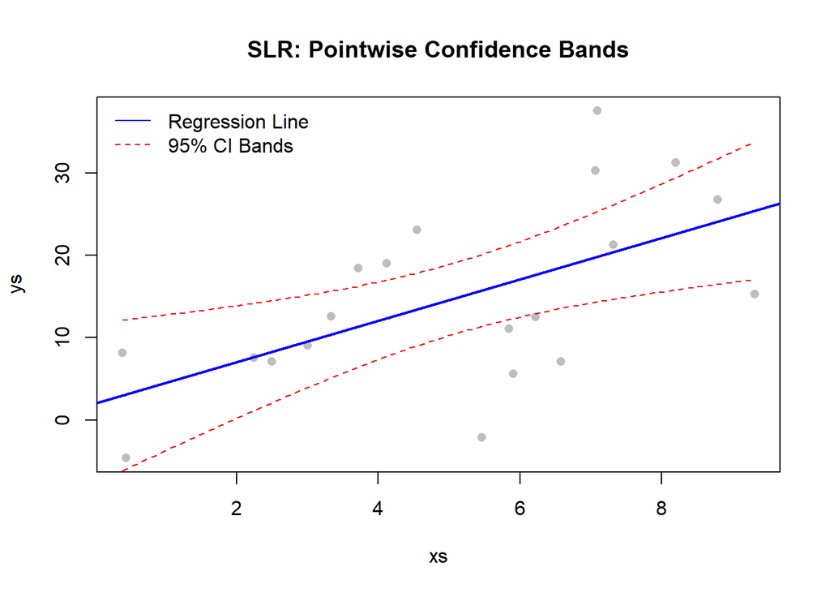

*Session 3 | Inference and Matrix Foundations in SLR*